# R 패키지 ggplot2을 이용한 자료의 시각화

서울시립대학교 통계학과 이용희

가을, 2017

# 1 `ggplot2` 패키지

`ggplot2` 패키지는 `R`에서 그림을 그리는 과정을 절차에 따른 요소(components)로 나누어서 각 요소를 차례대로 그림판에 추가하는 형식으로 구현된 점이 그 특징이다. 그림을 그리는 차례에 따른 각 요소는 다음과 같다.

- **data** 그림을 그릴 때 사용되는 데이터프레임(`dataframe`)
- **aesthetic mapping** 그림을 그릴 때 사용되는 변수들과 각 변수들이 가지는 역활과 특징(aesthetics)을 지정하는 요소 (`aes`)
- **geometric object** 그림의 형태를 지정하는 요소 (`geom_`)
- **statistical transformations** 각종 통계량을 계산하여 그림에 삽입 (`stat_`)
- **scales** 자료의 값에 따른 시각화 모양과 축의 비율 (`scale_`)
- **coordinate system** 두 축에 대한 특성을 설정 (`coor_`)
- **position adjustments** 두 개의 그림이 겹칠 때 위치 지정 (`position_`)
- **faceting** 범주형 변수에 의한 그룹에 의한 그림 행렬 지정 (`facet_`)
- **theme** 그림의 전체적인 배경을 변경 (`theme_`)

# 2 간단한 그림들

이제 필요한 패키지를 로딩하고 예제로 사용할 데이터프레임 `diamond`를 부른다. 데이터프레임 `diamond`은 54,000개의 다이아몬드들의 특성에 대한 변수들을 모아놓은 자료이다.

```r
options(scipen=999)  # turn off scientific notation like 1e+06
library(dplyr)
```

```r
library(tidyr)
library(ggplot2)
data("diamonds", package = "ggplot2")  # load the data
head(diamonds)
```

```
## # A tibble: 6 x 10
##   carat       cut color clarity depth table price     x     y     z
##   <dbl>     <ord> <ord>   <ord> <dbl> <dbl> <int> <dbl> <dbl> <dbl>
## 1  0.23     Ideal     E     SI2  61.5    55   326  3.95  3.98  2.43
## 2  0.21   Premium     E     SI1  59.8    61   326  3.89  3.84  2.31
## 3  0.23      Good     E     VS1  56.9    65   327  4.05  4.07  2.31
## 4  0.29   Premium     I     VS2  62.4    58   334  4.20  4.23  2.63
## 5  0.31      Good     J     SI2  63.3    58   335  4.34  4.35  2.75
## 6  0.24 Very Good     J    VVS2  62.8    57   336  3.94  3.96  2.48
```

## 2.1 히스토그램과 상자그림

아주 단순한 그림으로 `diamonds`자료에 있는 변수 `carat`(카렛, 무게)의 히스토그램을 그려보자.

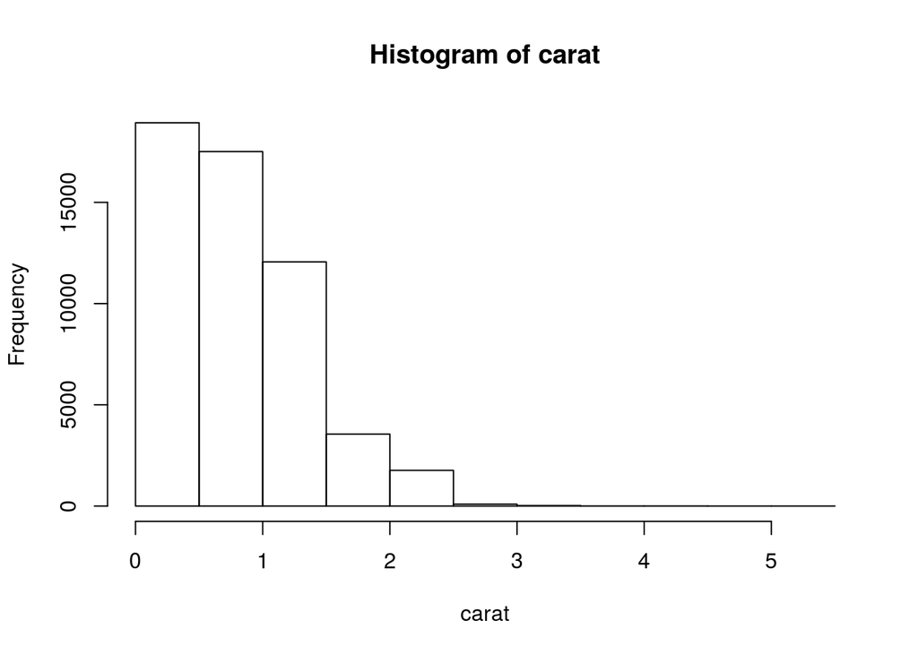

```r
with(diamonds,hist(carat))
```

히스토그램을 `ggplot2` 로 그리려면 다음과 명령어를 사용한다.

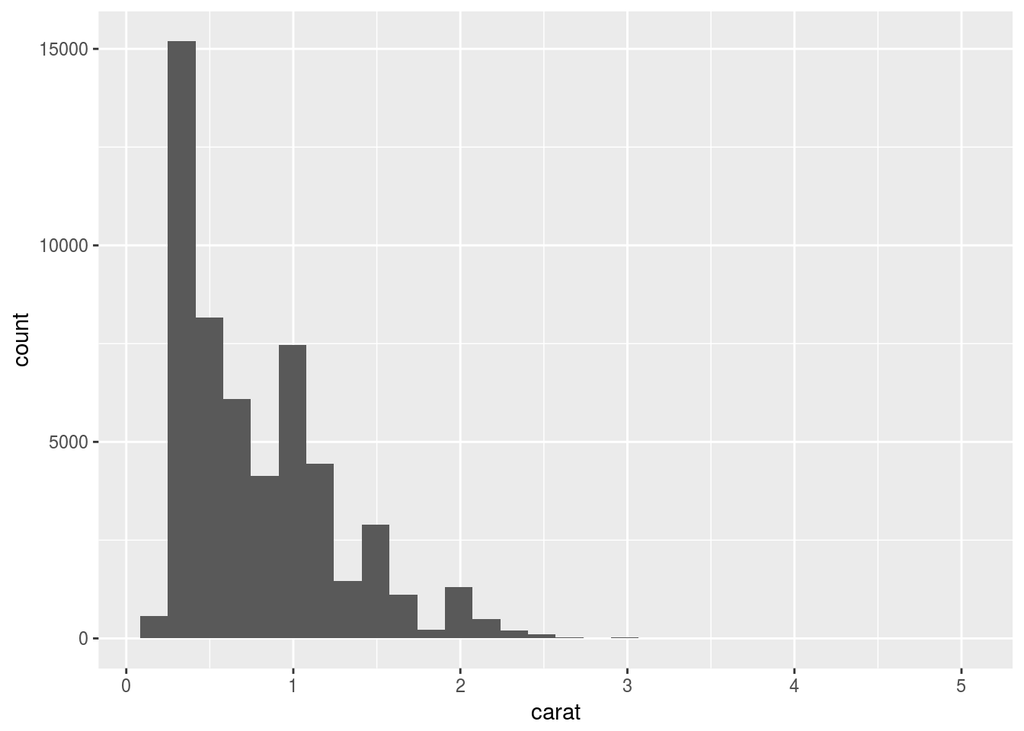

```r
ggplot(diamonds, aes(x = carat)) +  geom_histogram()
```

위의 명령어에서 `ggplot(diamonds, aes(x = carat))`은 사용할 데이터프레임인 `diamonds`를 지정하고 사용할 축과 해당하는 변수 `x=carat`을 `aes` 도움함수로 지정한다. 그리고 `+` 다음에 `geom_histogram()` 함수를 통하여 그림의 형태가 히스토그램임을 지정해준다.